# Exploratory Data Analysis of Palmer Penguins

19/03/2022

> Palmer penguin R package contains two datasets: `penguins_raw` and `penguins`. Today we’ll focus on a curated subset of the raw data in the package named `penguins` and as you can see from their name, penguins is pre-processed data.

Lets go through each stage of the data science project first!

- Import
- Tidy
- Transform
- Visualise
- Model (Not using that today!)
- Communicate

# Import: Load dataset and library on workspace.

- After installing the packages, you can load them by using the `library` function.
- There are two R packages that are used to transform and visualise data : `dplyr` and `ggplot2`. You can find these two combined with various other packages in `tidyverse`
- The dataset from the R package can be loaded using `data()`.

# Tidy

The data we have is already preprocessed therefore it is in tidy format.

# Summary of Dataset

- Before doing anything, we should first see the summary of Dataset!

```r
glimpse(penguins)
```

```
## Rows: 344
## Columns: 8
## $ species           <fct> Adelie, Adelie, Adelie, Adelie, Adelie, Adelie, Adel~
## $ island            <fct> Torgersen, Torgersen, Torgersen, Torgersen, Torgerse~
## $ bill_length_mm    <dbl> 39.1, 39.5, 40.3, NA, 36.7, 39.3, 38.9, 39.2, 34.1, ~
## $ bill_depth_mm     <dbl> 18.7, 17.4, 18.0, NA, 19.3, 20.6, 17.8, 19.6, 18.1, ~
## $ flipper_length_mm <int> 181, 186, 195, NA, 193, 190, 181, 195, 193, 190, 186~
## $ body_mass_g       <int> 3750, 3800, 3250, NA, 3450, 3650, 3625, 4675, 3475, ~
## $ sex               <fct> male, female, female, NA, female, male, female, male~
## $ year              <int> 2007, 2007, 2007, 2007, 2007, 2007, 2007, 2007, 2007~
```

The data has 344 rows or observations and 8 variables.

- Get data dictionary from the help file. Try ?penguins

```r
summary(penguins)
```

```
##       species          island    bill_length_mm  bill_depth_mm
##  Adelie   :152   Biscoe   :168   Min.   :32.10   Min.   :13.10
##  Chinstrap: 68   Dream    :124   1st Qu.:39.23   1st Qu.:15.60
##  Gentoo   :124   Torgersen: 52   Median :44.45   Median :17.30
##                                  Mean   :43.92   Mean   :17.15
##                                  3rd Qu.:48.50   3rd Qu.:18.70
##                                  Max.   :59.60   Max.   :21.50
##                                  NA's   :2       NA's   :2
##  flipper_length_mm  body_mass_g       sex           year
##  Min.   :172.0     Min.   :2700   female:165   Min.   :2007
##  1st Qu.:190.0     1st Qu.:3550   male  :168   1st Qu.:2007
##  Median :197.0     Median :4050   NA's  : 11   Median :2008
##  Mean   :200.9     Mean   :4202                Mean   :2008
##  3rd Qu.:213.0     3rd Qu.:4750                3rd Qu.:2009
##  Max.   :231.0     Max.   :6300                Max.   :2009
##  NA's   :2         NA's   :2
```

### What do you gather from here?

- The data gathered is from 2007-2009
- Three species : Adelie , Chinstrap, Gentoo
- 3 Island : Biscoe, Dream, Torgersen
- Has some unknown values

### You can visualise the data as a whole as well

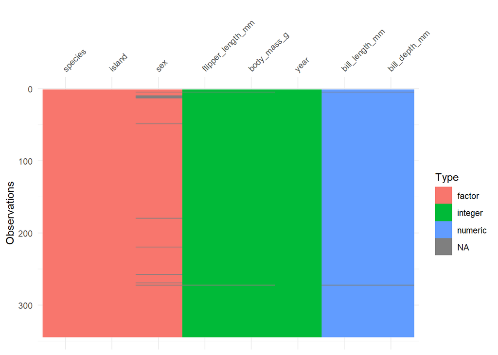

```r
#install.packages(visdat)
visdat::vis_dat(penguins)
```

# Transform

- select desired variables & filter out unknowns. You can also create new variables from existing variables.

```r
data_subset<- penguins%>%
  select(species,bill_depth_mm,flipper_length_mm,bill_length_mm)%>%
  filter(!is.na(flipper_length_mm),!is.na(bill_depth_mm),!is.na(bill_length_mm))%>%
  mutate(ratio=bill_depth_mm/bill_length_mm)
```

# Visualise

- You can use functions from ggplot2 package to create various visualisations.
- ggplot() creates a coordinate system that you can add layers to. The first argument of ggplot() is the dataset to use in the graph.
- ggplot2 comes with many geom functions that each add a different type of layer to a plot.
- Each geom function in ggplot2 takes a mapping argument. This defines how variables in your dataset are mapped to visual properties.
- The mapping argument is always paired with aes(), and the x and y arguments of aes() specify which variables to map to the x and y axes.
- You can also tweek the vis by adding other aesthetics by including things like the size, the shape, or the color of your points/graph.

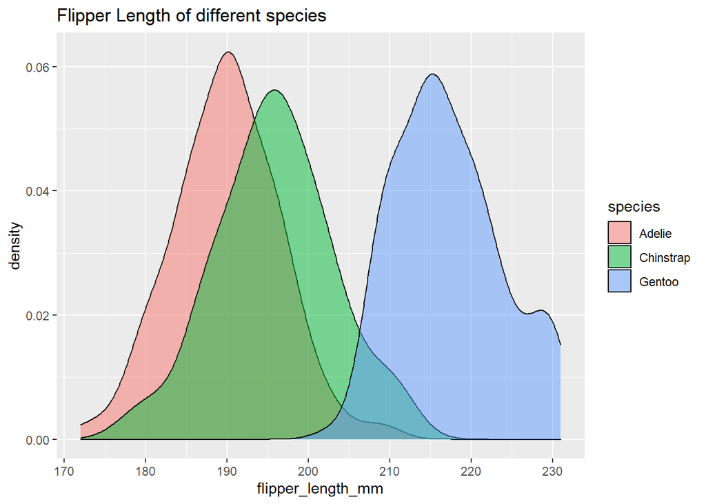

```r
  ggplot(data_subset)+
  geom_density(mapping = aes(x=flipper_length_mm,fill=species),alpha=0.5)+
  ggtitle("Flipper Length of different species")
```

- Alpha argument here controls the shading

You can do the same thing with histogram!

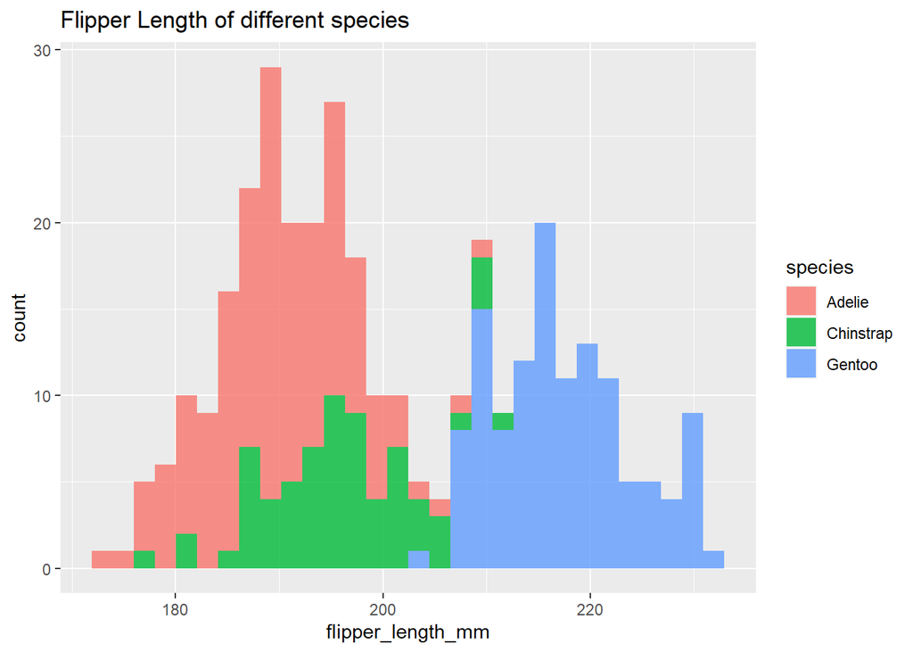

```r
data_subset%>%
  ggplot()+
  geom_histogram(mapping = aes(x=flipper_length_mm,fill=species),alpha=0.8)+
  ggtitle("Flipper Length of different species")
```